# Blog Your Solution: Red Wine Quality

# Business Understanding

### Problem Definition

This is a tidy data set, containing 1,599 red wines with 11 variables on the chemical properties of the wine. The quality of this red wine has been rated by at least 3 experts with values ranging from 0 (very bad) to 10 (very excellent). In this project, I am going to understand, prepare and model this dataset, while answering some important research questions. Get the data set from [here](https://s3.amazonaws.com/udacity-hosted-downloads/ud651/wineQualityReds.csv).

### Assess Situation

Of course it's logical to conclude that high quality wines are most expensive, but we must be able to know how to determine the quality of red wine, based on it's chemical components. If you are a consumer, you may stand the risk of buying low quality wine at very high prices. On the other hand, it's possible that a company will be more exposed to DBI if they do not understand fully how the wine quality is affected by it's chemical constituents.

### Goals for the Business

We are going to use this red wine data set to answer some questions usually asked by red wine coumers and it manufacturers

1. How do the acidity and quantity of chlorides affect red wine quality
2. Which is of high quality? Low alcoholic red wines or high alcoholic red wines?
3. How accurate is it to determine the quality of red wine from its chemical components?

# Data Understanding

In the code cell below we load the red wine quality dataset into pandas DataFrame. The dataset contains 1599 observations(rows of the resulting dataframe) and 11 variables (columns of the resulting dataframe) involved in assessing quality of red wine.

##### Load packages

```python
# import libraries
import pandas as pd
import numpy as np
from IPython.display import display # Allows the use of display() for DataFrames
import matplotlib.pyplot as plt
import seaborn as sns
from sklearn.svm import SVC
from sklearn.linear_model import LogisticRegression
from sklearn.metrics import confusion_matrix, classification_report
from sklearn.model_selection import train_test_split, cross_val_score, GridSearchCV
from sklearn.model_selection import cross_val_score
from sklearn.metrics import confusion_matrix
from sklearn import model_selection
import warnings; warnings.simplefilter('ignore')# suppress all warning messages
%matplotlib inline
```

```python
#load the data into dataframe
df=pd.read_csv("wineQualityReds.csv")
```

```python
#view data information
df.info()
```

```
<class 'pandas.core.frame.DataFrame'>
RangeIndex: 1599 entries, 0 to 1598
Data columns (total 13 columns):
Unnamed: 0              1599 non-null int64
fixed.acidity           1599 non-null float64
volatile.acidity        1599 non-null float64
citric.acid             1599 non-null float64
residual.sugar          1599 non-null float64
chlorides               1599 non-null float64
free.sulfur.dioxide     1599 non-null float64
total.sulfur.dioxide    1599 non-null float64
density                 1599 non-null float64
pH                      1599 non-null float64
sulphates               1599 non-null float64
alcohol                 1599 non-null float64
quality                 1599 non-null int64
dtypes: float64(11), int64(2)
memory usage: 162.5 KB
```

- Checking the information of this gata set tells us that there are no missing values, hence we confirm that this is tidy dataset

```python
# Checking fews entries and the columns of the dataset
df.head()
```

|  | Unnamed: 0 | fixed.acidity | volatile.acidity | citric.acid | residual.sugar | chlorides | free.sulfur.dioxide | total.sulfur.dioxide | density | pH | sulphates | alcohol | quality |
| --- | --- | --- | --- | --- | --- | --- | --- | --- | --- | --- | --- | --- | --- |
| 0 | 1 | 7.4 | 0.70 | 0.00 | 1.9 | 0.076 | 11.0 | 34.0 | 0.9978 | 3.51 | 0.56 | 9.4 | 5 |
| 1 | 2 | 7.8 | 0.88 | 0.00 | 2.6 | 0.098 | 25.0 | 67.0 | 0.9968 | 3.20 | 0.68 | 9.8 | 5 |
| 2 | 3 | 7.8 | 0.76 | 0.04 | 2.3 | 0.092 | 15.0 | 54.0 | 0.9970 | 3.26 | 0.65 | 9.8 | 5 |
| 3 | 4 | 11.2 | 0.28 | 0.56 | 1.9 | 0.075 | 17.0 | 60.0 | 0.9980 | 3.16 | 0.58 | 9.8 | 6 |
| 4 | 5 | 7.4 | 0.70 | 0.00 | 1.9 | 0.076 | 11.0 | 34.0 | 0.9978 | 3.51 | 0.56 | 9.4 | 5 |

It seems we have only one categorical variable (`quality`)

```python
# statistical description of the dataset.
df.describe()
```

|  | Unnamed: 0 | fixed.acidity | volatile.acidity | citric.acid | residual.sugar | chlorides | free.sulfur.dioxide | total.sulfur.dioxide | density | pH | sulphates | alcohol | quality |
| --- | --- | --- | --- | --- | --- | --- | --- | --- | --- | --- | --- | --- | --- |
| count | 1599.000000 | 1599.000000 | 1599.000000 | 1599.000000 | 1599.000000 | 1599.000000 | 1599.000000 | 1599.000000 | 1599.000000 | 1599.000000 | 1599.000000 | 1599.000000 | 1599.000000 |
| mean | 800.000000 | 8.319637 | 0.527821 | 0.270976 | 2.538806 | 0.087467 | 15.874922 | 46.467792 | 0.996747 | 3.311113 | 0.658149 | 10.422983 | 5.636023 |
| std | 461.735855 | 1.741096 | 0.179060 | 0.194801 | 1.409928 | 0.047065 | 10.460157 | 32.895324 | 0.001887 | 0.154386 | 0.169507 | 1.065668 | 0.807569 |
| min | 1.000000 | 4.600000 | 0.120000 | 0.000000 | 0.900000 | 0.012000 | 1.000000 | 6.000000 | 0.990070 | 2.740000 | 0.330000 | 8.400000 | 3.000000 |
| 25% | 400.500000 | 7.100000 | 0.390000 | 0.090000 | 1.900000 | 0.070000 | 7.000000 | 22.000000 | 0.995600 | 3.210000 | 0.550000 | 9.500000 | 5.000000 |
| 50% | 800.000000 | 7.900000 | 0.520000 | 0.260000 | 2.200000 | 0.079000 | 14.000000 | 38.000000 | 0.996750 | 3.310000 | 0.620000 | 10.200000 | 6.000000 |
| 75% | 1199.500000 | 9.200000 | 0.640000 | 0.420000 | 2.600000 | 0.090000 | 21.000000 | 62.000000 | 0.997835 | 3.400000 | 0.730000 | 11.100000 | 6.000000 |
| max | 1599.000000 | 15.900000 | 1.580000 | 1.000000 | 15.500000 | 0.611000 | 72.000000 | 289.000000 | 1.003690 | 4.010000 | 2.000000 | 14.900000 | 8.000000 |

- Among other information that can be extracted from the dataset, we can see that the highest wine quality has a quality rating value of 8 and the lowest wine quality has it quality value as 3

# Data preparation

### Identification of data issues

This is a tidy data set, meaning it's doesn't have missing values, this can be confirmed below.

```python
# Display the percentage of missing values in each feature
def missing_values(data):
    """
    Print out percentage of missing values in data set

    Parameter
    ---------
    data : DataFrame
        data set to explore

    Return
    ------
    Print out of features with more than )% of missing values
    """
    missing_data = []
    percentage_missing_data =(data.isnull().sum()/len(data))
    print("Percentage of Missing data")
    for x in range(len(percentage_missing_data)):
        if(percentage_missing_data[x] > 0):
            missing_data = percentage_missing_data.index[x]
            print("{} has {:.1f}% of data marked as NaNs".format(missing_data, (percentage_missing_data[x]*100)))

missing_values(df)
```

```
Percentage of Missing data
```

As seen above, there no missing values in the dataset. We will therefore try to check categorical variables. Normally, the pH value of a constituent can either be basic(greater than 8) , acidic (less 6) or neutral (7). let's try to categorize pH values

```python
data_df = df.copy()
data_df["cat_pH"] = ["Acidic" if i <6 else "Basic" for i in data_df["pH"]]
```

```python
data_df.cat_pH.value_counts()
```

```
Acidic    1599
Name: cat_pH, dtype: int64
```

- We can see that all red wines are acidic, hence can't be categorized.

Now, we will convert the Quality feature in binary categorical to be used for our model.

```python
test_data=df.copy()
test_data["Quality"] = ["Low_Quality" if i <=5 else "High_Quality" for i in test_data["quality"]]
```

```python
test_data.Quality.value_counts()
```

```
High_Quality    855
Low_Quality     744
Name: Quality, dtype: int64
```

test_data.head()

- We realize that there are more high quality red wines in the market than low quality red wines. But we must take note here that the difference is not large, hence, oe needs to be very careful when buying red wine, as there is a very high percentage of Low quality wine in the market.

## Question 1: How do the acidity and quantity of chlorides affect red wine quality?

```python
#Group data by Quality to get some insights
test_data.groupby("Quality")['pH']
#get the average values of fixed acidity and chlorides
test_data.groupby('Quality')[["fixed.acidity","chlorides"]].mean()
```

| Quality | fixed.acidity | chlorides |
| --- | --- | --- |
| High_Quality | 8.474035 | 0.082661 |
| Low_Quality | 8.142204 | 0.092989 |

We notice from the table above that the average acidity of red wines is higher for high quality wines and lower for low quality wines. On the otherhand, the average chlorides quantity is higher for low quality wines and lower for high quality wines. These mean that, companies are advised to increase the acidity of red wine and reduce the chlorides contents to increase quality.

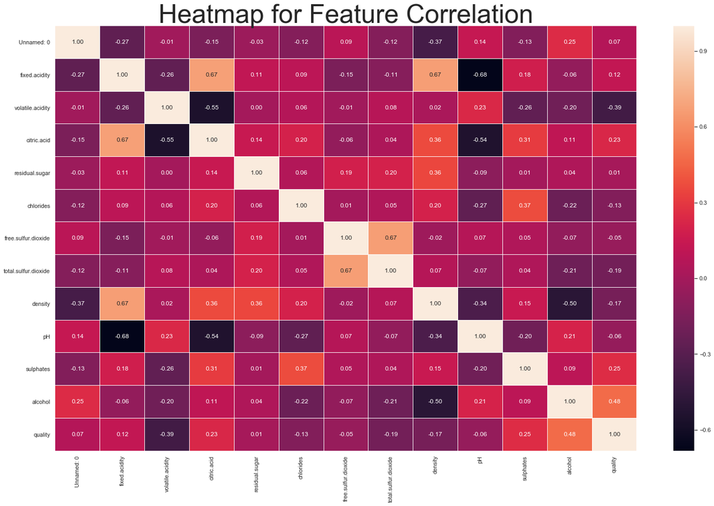

```python
# Check correlation between features
import seaborn as sns; sns.set()
fig, ax = plt.subplots(figsize=(25,15))
sns.heatmap(test_data.corr(), annot=True, ax=ax, linewidth=.01, fmt='.2f')
sns.set(font_scale=2)
plt.title("Heatmap for Feature Correlation",fontsize=50)
# Bigger than normal fonts
sns.set(font_scale=2)
plt.show()
```

```python
test_data["Alcohol"] = ["Lowly_Alcoholic" if i <10 else "Highly_Alcoholic" for i in test_data["alcohol"]]
```

```python
test_data
```

|  | Unnamed: 0 | fixed.acidity | volatile.acidity | citric.acid | residual.sugar | chlorides | free.sulfur.dioxide | total.sulfur.dioxide | density | pH | sulphates | alcohol | quality | Quality | Alcohol |
| --- | --- | --- | --- | --- | --- | --- | --- | --- | --- | --- | --- | --- | --- | --- | --- |
| 0 | 1 | 7.4 | 0.700 | 0.00 | 1.9 | 0.076 | 11.0 | 34.0 | 0.99780 | 3.51 | 0.56 | 9.4 | 5 | Low_Quality | Lowly_Alcoholic |
| 1 | 2 | 7.8 | 0.880 | 0.00 | 2.6 | 0.098 | 25.0 | 67.0 | 0.99680 | 3.20 | 0.68 | 9.8 | 5 | Low_Quality | Lowly_Alcoholic |
| 2 | 3 | 7.8 | 0.760 | 0.04 | 2.3 | 0.092 | 15.0 | 54.0 | 0.99700 | 3.26 | 0.65 | 9.8 | 5 | Low_Quality | Lowly_Alcoholic |
| 3 | 4 | 11.2 | 0.280 | 0.56 | 1.9 | 0.075 | 17.0 | 60.0 | 0.99800 | 3.16 | 0.58 | 9.8 | 6 | High_Quality | Lowly_Alcoholic |
| 4 | 5 | 7.4 | 0.700 | 0.00 | 1.9 | 0.076 | 11.0 | 34.0 | 0.99780 | 3.51 | 0.56 | 9.4 | 5 | Low_Quality | Lowly_Alcoholic |
| 5 | 6 | 7.4 | 0.660 | 0.00 | 1.8 | 0.075 | 13.0 | 40.0 | 0.99780 | 3.51 | 0.56 | 9.4 | 5 | Low_Quality | Lowly_Alcoholic |
| 6 | 7 | 7.9 | 0.600 | 0.06 | 1.6 | 0.069 | 15.0 | 59.0 | 0.99640 | 3.30 | 0.46 | 9.4 | 5 | Low_Quality | Lowly_Alcoholic |
| 7 | 8 | 7.3 | 0.650 | 0.00 | 1.2 | 0.065 | 15.0 | 21.0 | 0.99460 | 3.39 | 0.47 | 10.0 | 7 | High_Quality | Highly_Alcoholic |
| 8 | 9 | 7.8 | 0.580 | 0.02 | 2.0 | 0.073 | 9.0 | 18.0 | 0.99680 | 3.36 | 0.57 | 9.5 | 7 | High_Quality | Lowly_Alcoholic |
| 9 | 10 | 7.5 | 0.500 | 0.36 | 6.1 | 0.071 | 17.0 | 102.0 | 0.99780 | 3.35 | 0.80 | 10.5 | 5 | Low_Quality | Highly_Alcoholic |
| 10 | 11 | 6.7 | 0.580 | 0.08 | 1.8 | 0.097 | 15.0 | 65.0 | 0.99590 | 3.28 | 0.54 | 9.2 | 5 | Low_Quality | Lowly_Alcoholic |
| 11 | 12 | 7.5 | 0.500 | 0.36 | 6.1 | 0.071 | 17.0 | 102.0 | 0.99780 | 3.35 | 0.80 | 10.5 | 5 | Low_Quality | Highly_Alcoholic |
| 12 | 13 | 5.6 | 0.615 | 0.00 | 1.6 | 0.089 | 16.0 | 59.0 | 0.99430 | 3.58 | 0.52 | 9.9 | 5 | Low_Quality | Lowly_Alcoholic |
| 13 | 14 | 7.8 | 0.610 | 0.29 | 1.6 | 0.114 | 9.0 | 29.0 | 0.99740 | 3.26 | 1.56 | 9.1 | 5 | Low_Quality | Lowly_Alcoholic |
| 14 | 15 | 8.9 | 0.620 | 0.18 | 3.8 | 0.176 | 52.0 | 145.0 | 0.99860 | 3.16 | 0.88 | 9.2 | 5 | Low_Quality | Lowly_Alcoholic |
| 15 | 16 | 8.9 | 0.620 | 0.19 | 3.9 | 0.170 | 51.0 | 148.0 | 0.99860 | 3.17 | 0.93 | 9.2 | 5 | Low_Quality | Lowly_Alcoholic |
| 16 | 17 | 8.5 | 0.280 | 0.56 | 1.8 | 0.092 | 35.0 | 103.0 | 0.99690 | 3.30 | 0.75 | 10.5 | 7 | High_Quality | Highly_Alcoholic |
| 17 | 18 | 8.1 | 0.560 | 0.28 | 1.7 | 0.368 | 16.0 | 56.0 | 0.99680 | 3.11 | 1.28 | 9.3 | 5 | Low_Quality | Lowly_Alcoholic |
| 18 | 19 | 7.4 | 0.590 | 0.08 | 4.4 | 0.086 | 6.0 | 29.0 | 0.99740 | 3.38 | 0.50 | 9.0 | 4 | Low_Quality | Lowly_Alcoholic |
| 19 | 20 | 7.9 | 0.320 | 0.51 | 1.8 | 0.341 | 17.0 | 56.0 | 0.99690 | 3.04 | 1.08 | 9.2 | 6 | High_Quality | Lowly_Alcoholic |
| 20 | 21 | 8.9 | 0.220 | 0.48 | 1.8 | 0.077 | 29.0 | 60.0 | 0.99680 | 3.39 | 0.53 | 9.4 | 6 | High_Quality | Lowly_Alcoholic |
| 21 | 22 | 7.6 | 0.390 | 0.31 | 2.3 | 0.082 | 23.0 | 71.0 | 0.99820 | 3.52 | 0.65 | 9.7 | 5 | Low_Quality | Lowly_Alcoholic |
| 22 | 23 | 7.9 | 0.430 | 0.21 | 1.6 | 0.106 | 10.0 | 37.0 | 0.99660 | 3.17 | 0.91 | 9.5 | 5 | Low_Quality | Lowly_Alcoholic |
| 23 | 24 | 8.5 | 0.490 | 0.11 | 2.3 | 0.084 | 9.0 | 67.0 | 0.99680 | 3.17 | 0.53 | 9.4 | 5 | Low_Quality | Lowly_Alcoholic |
| 24 | 25 | 6.9 | 0.400 | 0.14 | 2.4 | 0.085 | 21.0 | 40.0 | 0.99680 | 3.43 | 0.63 | 9.7 | 6 | High_Quality | Lowly_Alcoholic |
| 25 | 26 | 6.3 | 0.390 | 0.16 | 1.4 | 0.080 | 11.0 | 23.0 | 0.99550 | 3.34 | 0.56 | 9.3 | 5 | Low_Quality | Lowly_Alcoholic |
| 26 | 27 | 7.6 | 0.410 | 0.24 | 1.8 | 0.080 | 4.0 | 11.0 | 0.99620 | 3.28 | 0.59 | 9.5 | 5 | Low_Quality | Lowly_Alcoholic |
| 27 | 28 | 7.9 | 0.430 | 0.21 | 1.6 | 0.106 | 10.0 | 37.0 | 0.99660 | 3.17 | 0.91 | 9.5 | 5 | Low_Quality | Lowly_Alcoholic |
| 28 | 29 | 7.1 | 0.710 | 0.00 | 1.9 | 0.080 | 14.0 | 35.0 | 0.99720 | 3.47 | 0.55 | 9.4 | 5 | Low_Quality | Lowly_Alcoholic |
| 29 | 30 | 7.8 | 0.645 | 0.00 | 2.0 | 0.082 | 8.0 | 16.0 | 0.99640 | 3.38 | 0.59 | 9.8 | 6 | High_Quality | Lowly_Alcoholic |
| ... | ... | ... | ... | ... | ... | ... | ... | ... | ... | ... | ... | ... | ... | ... | ... |
| 1569 | 1570 | 6.2 | 0.510 | 0.14 | 1.9 | 0.056 | 15.0 | 34.0 | 0.99396 | 3.48 | 0.57 | 11.5 | 6 | High_Quality | Highly_Alcoholic |
| 1570 | 1571 | 6.4 | 0.360 | 0.53 | 2.2 | 0.230 | 19.0 | 35.0 | 0.99340 | 3.37 | 0.93 | 12.4 | 6 | High_Quality | Highly_Alcoholic |
| 1571 | 1572 | 6.4 | 0.380 | 0.14 | 2.2 | 0.038 | 15.0 | 25.0 | 0.99514 | 3.44 | 0.65 | 11.1 | 6 | High_Quality | Highly_Alcoholic |
| 1572 | 1573 | 7.3 | 0.690 | 0.32 | 2.2 | 0.069 | 35.0 | 104.0 | 0.99632 | 3.33 | 0.51 | 9.5 | 5 | Low_Quality | Lowly_Alcoholic |
| 1573 | 1574 | 6.0 | 0.580 | 0.20 | 2.4 | 0.075 | 15.0 | 50.0 | 0.99467 | 3.58 | 0.67 | 12.5 | 6 | High_Quality | Highly_Alcoholic |
| 1574 | 1575 | 5.6 | 0.310 | 0.78 | 13.9 | 0.074 | 23.0 | 92.0 | 0.99677 | 3.39 | 0.48 | 10.5 | 6 | High_Quality | Highly_Alcoholic |
| 1575 | 1576 | 7.5 | 0.520 | 0.40 | 2.2 | 0.060 | 12.0 | 20.0 | 0.99474 | 3.26 | 0.64 | 11.8 | 6 | High_Quality | Highly_Alcoholic |
| 1576 | 1577 | 8.0 | 0.300 | 0.63 | 1.6 | 0.081 | 16.0 | 29.0 | 0.99588 | 3.30 | 0.78 | 10.8 | 6 | High_Quality | Highly_Alcoholic |
| 1577 | 1578 | 6.2 | 0.700 | 0.15 | 5.1 | 0.076 | 13.0 | 27.0 | 0.99622 | 3.54 | 0.60 | 11.9 | 6 | High_Quality | Highly_Alcoholic |
| 1578 | 1579 | 6.8 | 0.670 | 0.15 | 1.8 | 0.118 | 13.0 | 20.0 | 0.99540 | 3.42 | 0.67 | 11.3 | 6 | High_Quality | Highly_Alcoholic |
| 1579 | 1580 | 6.2 | 0.560 | 0.09 | 1.7 | 0.053 | 24.0 | 32.0 | 0.99402 | 3.54 | 0.60 | 11.3 | 5 | Low_Quality | Highly_Alcoholic |
| 1580 | 1581 | 7.4 | 0.350 | 0.33 | 2.4 | 0.068 | 9.0 | 26.0 | 0.99470 | 3.36 | 0.60 | 11.9 | 6 | High_Quality | Highly_Alcoholic |
| 1581 | 1582 | 6.2 | 0.560 | 0.09 | 1.7 | 0.053 | 24.0 | 32.0 | 0.99402 | 3.54 | 0.60 | 11.3 | 5 | Low_Quality | Highly_Alcoholic |
| 1582 | 1583 | 6.1 | 0.715 | 0.10 | 2.6 | 0.053 | 13.0 | 27.0 | 0.99362 | 3.57 | 0.50 | 11.9 | 5 | Low_Quality | Highly_Alcoholic |
| 1583 | 1584 | 6.2 | 0.460 | 0.29 | 2.1 | 0.074 | 32.0 | 98.0 | 0.99578 | 3.33 | 0.62 | 9.8 | 5 | Low_Quality | Lowly_Alcoholic |
| 1584 | 1585 | 6.7 | 0.320 | 0.44 | 2.4 | 0.061 | 24.0 | 34.0 | 0.99484 | 3.29 | 0.80 | 11.6 | 7 | High_Quality | Highly_Alcoholic |
| 1585 | 1586 | 7.2 | 0.390 | 0.44 | 2.6 | 0.066 | 22.0 | 48.0 | 0.99494 | 3.30 | 0.84 | 11.5 | 6 | High_Quality | Highly_Alcoholic |
| 1586 | 1587 | 7.5 | 0.310 | 0.41 | 2.4 | 0.065 | 34.0 | 60.0 | 0.99492 | 3.34 | 0.85 | 11.4 | 6 | High_Quality | Highly_Alcoholic |
| 1587 | 1588 | 5.8 | 0.610 | 0.11 | 1.8 | 0.066 | 18.0 | 28.0 | 0.99483 | 3.55 | 0.66 | 10.9 | 6 | High_Quality | Highly_Alcoholic |
| 1588 | 1589 | 7.2 | 0.660 | 0.33 | 2.5 | 0.068 | 34.0 | 102.0 | 0.99414 | 3.27 | 0.78 | 12.8 | 6 | High_Quality | Highly_Alcoholic |
| 1589 | 1590 | 6.6 | 0.725 | 0.20 | 7.8 | 0.073 | 29.0 | 79.0 | 0.99770 | 3.29 | 0.54 | 9.2 | 5 | Low_Quality | Lowly_Alcoholic |
| 1590 | 1591 | 6.3 | 0.550 | 0.15 | 1.8 | 0.077 | 26.0 | 35.0 | 0.99314 | 3.32 | 0.82 | 11.6 | 6 | High_Quality | Highly_Alcoholic |
| 1591 | 1592 | 5.4 | 0.740 | 0.09 | 1.7 | 0.089 | 16.0 | 26.0 | 0.99402 | 3.67 | 0.56 | 11.6 | 6 | High_Quality | Highly_Alcoholic |
| 1592 | 1593 | 6.3 | 0.510 | 0.13 | 2.3 | 0.076 | 29.0 | 40.0 | 0.99574 | 3.42 | 0.75 | 11.0 | 6 | High_Quality | Highly_Alcoholic |
| 1593 | 1594 | 6.8 | 0.620 | 0.08 | 1.9 | 0.068 | 28.0 | 38.0 | 0.99651 | 3.42 | 0.82 | 9.5 | 6 | High_Quality | Lowly_Alcoholic |
| 1594 | 1595 | 6.2 | 0.600 | 0.08 | 2.0 | 0.090 | 32.0 | 44.0 | 0.99490 | 3.45 | 0.58 | 10.5 | 5 | Low_Quality | Highly_Alcoholic |
| 1595 | 1596 | 5.9 | 0.550 | 0.10 | 2.2 | 0.062 | 39.0 | 51.0 | 0.99512 | 3.52 | 0.76 | 11.2 | 6 | High_Quality | Highly_Alcoholic |
| 1596 | 1597 | 6.3 | 0.510 | 0.13 | 2.3 | 0.076 | 29.0 | 40.0 | 0.99574 | 3.42 | 0.75 | 11.0 | 6 | High_Quality | Highly_Alcoholic |
| 1597 | 1598 | 5.9 | 0.645 | 0.12 | 2.0 | 0.075 | 32.0 | 44.0 | 0.99547 | 3.57 | 0.71 | 10.2 | 5 | Low_Quality | Highly_Alcoholic |
| 1598 | 1599 | 6.0 | 0.310 | 0.47 | 3.6 | 0.067 | 18.0 | 42.0 | 0.99549 | 3.39 | 0.66 | 11.0 | 6 | High_Quality | Highly_Alcoholic |

1599 rows × 15 columns

### Question 2: Which is of high quality? Low alcoholic red wines or high alcoholic red wines?

```
Text(0,0.5,'Counts')
```

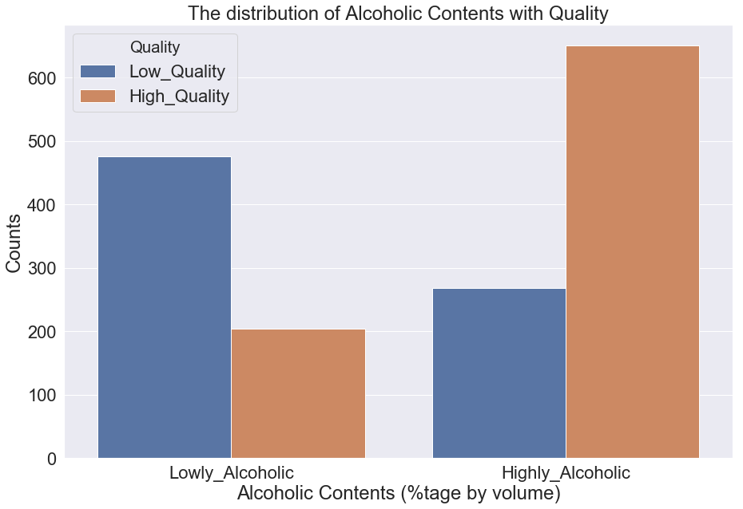

```python
#figure size
plt.figure(figsize=(15,10))
sns.countplot(x="Alcohol",hue="Quality",data=test_data)
#set plot title
plt.title('The distribution of Alcoholic Contents with Quality')

# Set x-axis label
plt.xlabel('Alcoholic Contents (%tage by volume)')

# Set y-axis label
plt.ylabel('Counts')
```

As we can see above, low quality red wines are mostly of low alcoholic contents, while high quality red wines are mostly of high alcoholic content. This implies that a consumer can go for highly alcoholic redwines to increase the chances of buying a high quality wine.

```python
test_data["Qualities"] = [1 if i =="High_Quality" else 0 for i in test_data["Quality"]]
```

#### Create dummy variables

That is variables with only two values, zero and one

```python
#Get categorical variable
cat_data = test_data.select_dtypes(include=['object'])
```

```python
#Create dummy variables
for cat in cat_data:
    cat_list='cat'+'_'+cat
    cat_list = pd.get_dummies(test_data[cat], prefix=cat)
    encode_data_cat=test_data.join(cat_list)
    test_data=encode_data_cat
encode_data_vars=test_data.columns.values.tolist()
work_data=[i for i in encode_data_vars if i not in cat_data]
```

```python
work_data
```

```
['Unnamed: 0',
 'fixed.acidity',
 'volatile.acidity',
 'citric.acid',
 'residual.sugar',
 'chlorides',
 'free.sulfur.dioxide',
 'total.sulfur.dioxide',
 'density',
 'pH',
 'sulphates',
 'alcohol',
 'quality',
 'Qualities',
 'Quality_High_Quality',
 'Quality_Low_Quality',
 'Alcohol_Highly_Alcoholic',
 'Alcohol_Lowly_Alcoholic']
```

```python
#final data set
final_data=test_data[work_data]
final_data_vars=final_data.columns.values.tolist()
target='Qualities'
y = final_data[target] # target set
# Collect final data ready for training
my_data=final_data.copy()
my_data=my_data.drop(my_data.columns[my_data.columns.str.contains('unnamed',case = False)],axis = 1)
my_data=my_data.drop(['quality', 'Qualities','Quality_High_Quality','Quality_Low_Quality'], axis=1)
```

```python
# get the predictors variables
predictors=[i for i in my_data]
X = my_data[predictors] # predictors set
```

# Analysis and Modeling

#### Analysizing the data

```
array([[<matplotlib.axes._subplots.AxesSubplot object at 0x000001B6EEE73DD8>,
      dtype=object)
```

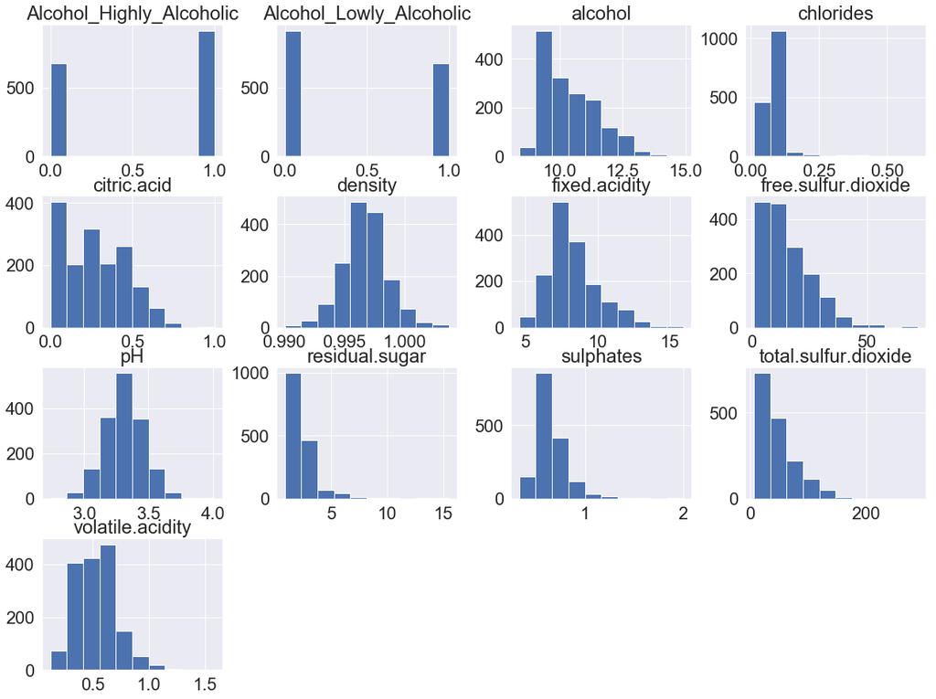

```python
#check the distributions of the different predictors variables
my_data.hist(figsize=(20,15))
```

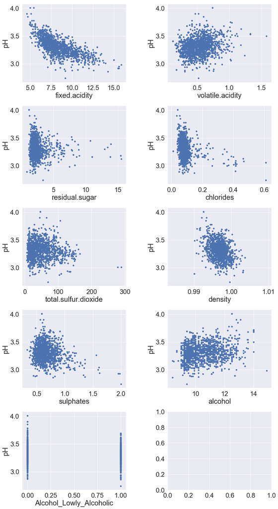

```python
# Compare numerical features with alcoholic content
fig, ax = plt.subplots(5,2, figsize=(15,30))
j,k = 0,0
#create a scatterplot for all variables against pH
for i, feat in enumerate(my_data.columns):
    if j < 5:
        if k < 2:
            my_data.plot(x=feat, y='pH', kind='scatter',  ax=ax[j][k], legend=False)
            k=k+1
        else:
            k=0
            j=j+1
plt.subplots_adjust(hspace=0.30, wspace=0.40)
plt.show()
```

## Question 3: How accurate is it to determine the quality of red wine from its chemical components?

To answer this question, we need modeling, we will exploit two models.

## Modelling

We are going to use two models(Logistic Regression Model, Support Vector Classifier) and then select the best.

##### Split the dataset into training and testing sets

```python
# Here we would also split the data into a training and testing set
X_train, X_test, y_train, y_test = train_test_split(X, y, test_size =0.30, random_state=42)
```

### Model 1: Logistic Regression

```python
lgr = LogisticRegression()
lgr.fit(X_train, y_train)
lgr_predicted = lgr.predict(X_test)
print('Accuracy of logistic regression on test set: {:.3f}'.format(lgr.score(X_test, y_test)))
```

```
Accuracy of logistic regression on test set: 0.740
```

```python
print(classification_report(y_test, lgr_predicted))
```

```
             precision    recall  f1-score   support

          0       0.71      0.71      0.71       213
          1       0.77      0.76      0.77       267

avg / total       0.74      0.74      0.74       480
```

### Model 2: Support Vector Classifier

```python
svc = SVC()
svc.fit(X_train, y_train)
svc_predicted = svc.predict(X_test)

print('Accuracy of Support Vector Classifier on test set: {:.2f}'.format(svc.score(X_test, y_test)))
```

```
Accuracy of Support Vector Classifier on test set: 0.69
```

### Validation

To improve the accuracy of our models, we must do this by tuning hyperpareameters through GridSearchCV and using Cross Validaton Score to select the best and optimized model our predictions.

#### Cross Validation

Cross validation is aimed at avoiding overfitting and giving a more precise prediction for each observation dataset. 10-fold Cross-Validation will be used to train our Logistic Regression and the support vector classifier models.

```python
#setting the default kfold value
kfold = model_selection.KFold(n_splits=10, random_state=7)
```

```python
#crossvalidating the logistic regression model 10kfold
scoring = 'accuracy'
results = model_selection.cross_val_score(lgr, X_train, y_train, cv=kfold, scoring=scoring)
print("Average accuracy for Logistic Regression: %.2f" % (results.mean()))

#cross validation average accuracy for Vector Support Classifier 10kfold
svc_eval = cross_val_score(estimator = svc, X = X_train, y = y_train, cv=kfold, scoring=scoring)
print('Average accuracy for support vector classifier: %.2f'%(svc_eval.mean()))
```

```
Average accuracy for Logistic Regression: 0.75
Average accuracy for support vector classifier: 0.70
```

#### Tuning Hyperparameter using GridSearchCV

here we will test various hyperparameters using the GridSearchCV for both models

```python
# Create regularization hyperparameter space
C_space = np.logspace(0, 2, 20)
```

```python
# Creating the penalty space
penalty = ['l1', 'l2']
hyperparameters = dict(C=C_space, penalty=penalty)

#grid searching with 10-fold cross validation
clf = GridSearchCV(lgr, hyperparameters, cv=10, verbose=0)
# Fitting the grid search
best_model = clf.fit(X, y)

# best hyperparameters
s_penalty=best_model.best_estimator_.get_params()['penalty']
s_c=best_model.best_estimator_.get_params()['C']
# Get the resulting accuracy
lgr_search = LogisticRegression(penalty=s_penalty,C=s_c)
lgr_search.fit(X_train, y_train)
predicted_lgr_search = lgr_search.predict(X_test)

print('Accuracy of logistic regression on test set: {:.2f}'.format(lgr_search.score(X_test, y_test)))
```

```
Accuracy of logistic regression on test set: 0.74
```

```python
# Setup the hyperparameter grid
param_grid = {'C': C_space}

# GridSearchCV Instantiation : logreg_cv
svc_search = GridSearchCV(svc, param_grid, scoring='accuracy', cv=10)
# Fit it to the data
svc_search.fit(X_train,y_train)

# Get resulting accuracy
c_slected = svc_search.best_params_.get('C')
svc_search= SVC(C=c_slected)
svc_search.fit(X_train, y_train)
predicted_svc_search = svc_search.predict(X_test)

print('Accuracy of Vector Support Classifier on test set: {:.2f}'.format(svc_search.score(X_test, y_test)))
```

```
Accuracy of Vector Support Classifier on test set: 0.70
```

- After GridSearchCV hyperparameters tuning applied for both models. Logistic Regression model performed(74%) better than the Support Vector classifier model(70%). Therefore, we selected the Logistic regression model.

##### Checking the precision, recall, F-score, support and the confusion matrix

The precision = `true positive` / (`true positive` + `false ppositive`).

Recall=`True Predicted Positive`/`Total Actuall positive`

The F1-Score is the `balance between Precision and Recall`.

The the number of occurrences of each class in y_test is the Support.

```python
# calculation of precision, recall, F-score, support and the confusion matrix.
print(classification_report(y_test,predicted_lgr_search))
# Calculating the confusion matrix
print(confusion_matrix(y_test, predicted_lgr_search))
```

```
             precision    recall  f1-score   support

          0       0.70      0.73      0.71       213
          1       0.78      0.75      0.76       267

avg / total       0.74      0.74      0.74       480

[[155  58]
 [ 67 200]]
```

Observations

```python
predicted_data=X_test.copy()
predicted_data['Quality'] = predicted_lgr_search
```

```python
predicted_data["Quality"] = ["High Quality" if i ==1 else "Low Quality" for i in predicted_data["Quality"]]
```

```
Text(69.8443,0.5,'Alcoholic contents (% by volume)')
```

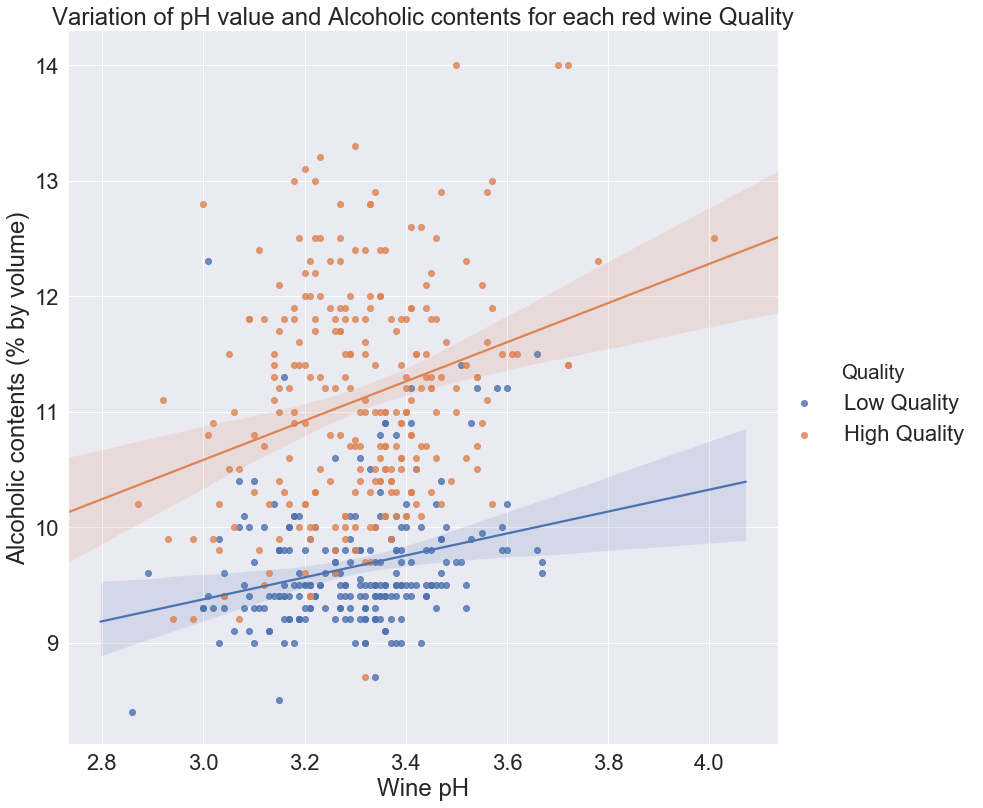

```python
#figure size
plt.figure()
#ploting
sns.lmplot(x="pH", y="alcohol",data=predicted_data, hue="Quality",size=11.5 )
#set plot title
plt.title('Variation of pH value and Alcoholic contents for each red wine Quality')

# Set x-axis label
plt.xlabel('Wine pH')

# Set y-axis label
plt.ylabel('Alcoholic contents (% by volume)')
```

- As we can see from above, and thanks to our prediction, we can deduce that wine most red wines with high alcoholic contents are more likely to be of high quality. since the quantity of alcohol increases with increase pH, increasing the pH will increase the alcholic content and hence the red wine quality. Therefore, consumers who have little knowledge about wine qualities should go for high alcoholic wines. This predicted result simply suggests that the higher the alcoholic content of red wine, the higher it's quality, which is inline we what we got in question 2. According to our model, this result is 74% accurate.